# Assignment 4

Yerin Jung

6/15/2018

#########Set Up###########

```r
#install.packages("zipcode")
#install.packages("DataExplorer")
library(dplyr)
library(DataExplorer)
#library(xda)
library(ggplot2)
library(plotly)
library(data.table)
library(zipcode)
suppressPackageStartupMessages(library(tidyverse))
library(stringr)
#library(ggthemes)
suppressPackageStartupMessages(library(maps))
```

```r
#setwd("/Users/Jung-yerin/Desktop/SUMMER_2018/AD/AnomalyDetection/week4")
payment <- read_csv("inpatientCharges.csv")
```

```r
# Changing column names to remove space
names(payment) <- c("DRG_Def", "Pro_Id", "Pro_Name","Pro_Add","Pro_City","Pro_State","Pro_Zip",
                    "HRR","Tot_Discharges","Avg_Cov_Charges","Avg_Tot_Payments","Avg_Med_Payments")
summary(payment)
```

```
##    DRG_Def              Pro_Id         Pro_Name           Pro_Add
##  Length:201876      Min.   : 10001   Length:201876      Length:201876
##  Class :character   1st Qu.:110079   Class :character   Class :character
##  Mode  :character   Median :240106   Mode  :character   Mode  :character
##                     Mean   :255739
##                     3rd Qu.:380027
##                     Max.   :670100
##    Pro_City          Pro_State            Pro_Zip          HRR
##  Length:201876      Length:201876      Min.   : 1040   Length:201876
##  Class :character   Class :character   1st Qu.:25301   Class :character
##  Mode  :character   Mode  :character   Median :43725   Mode  :character
##                                        Mean   :47051
##                                        3rd Qu.:71901
##                                        Max.   :99801
##  Tot_Discharges    Avg_Cov_Charges   Avg_Tot_Payments Avg_Med_Payments
##  Min.   :  11.00   Min.   :   1715   Min.   :  2420   Min.   :   659.3
##  1st Qu.:  15.00   1st Qu.:  21735   1st Qu.:  6261   1st Qu.:  4982.4
##  Median :  22.00   Median :  36050   Median :  9185   Median :  7680.9
##  Mean   :  36.82   Mean   :  55009   Mean   : 13220   Mean   : 11213.9
##  3rd Qu.:  39.00   3rd Qu.:  63474   3rd Qu.: 14655   3rd Qu.: 12442.5
##  Max.   :3990.00   Max.   :2794184   Max.   :449486   Max.   :417977.3
```

```r
# Parsing the numbers from Drug definition to see graphs effectively
payment <- payment %>%
  mutate(DRG_Num=substr(x = DRG_Def, start=1, stop=3))
```

# 1 Comparing Standardized Total Payment with The Other Providers

## 1.1 Lead

Generally, total payment of a care depends on the region(state) and type of drug function.  
As such, to see whether there is abnormally high total payment (`Avg_Tot_Payments`), I decided to standardize the value, using the mean and standard deviation of `Avg_Tot_Payments` grouped by Drug Definition (`Drug_Num`) and Provider State (`Pro_State`).

To do so, first, I should count the number of providers in each drug definition group. If there are just a few numbers of providers in the group, it might be less rational to compare the total payments. (In many cases there was only one provider in a drug function group.)

## 1.2 EDA

```r
# Making groups dependin on the number of providers in each drug group
payment1 <- payment %>%
  group_by(DRG_Def) %>%
  mutate(n_row_group=n())%>%
  ungroup()%>%
  mutate(group_class= cut(n_row_group, breaks = 3, labels = c("1_to_945", "946_to_1890", "1890_to_2837")))

payment1 %>%
  select(DRG_Def,group_class) %>%
  tail()
```

```
## # A tibble: 6 x 2
##   DRG_Def                                                      group_class
##   <chr>                                                        <fct>
## 1 988 - NON-EXTENSIVE O.R. PROC UNRELATED TO PRINCIPAL DIAGNO~ 1_to_945
## 2 988 - NON-EXTENSIVE O.R. PROC UNRELATED TO PRINCIPAL DIAGNO~ 1_to_945
## 3 988 - NON-EXTENSIVE O.R. PROC UNRELATED TO PRINCIPAL DIAGNO~ 1_to_945
## 4 988 - NON-EXTENSIVE O.R. PROC UNRELATED TO PRINCIPAL DIAGNO~ 1_to_945
## 5 988 - NON-EXTENSIVE O.R. PROC UNRELATED TO PRINCIPAL DIAGNO~ 1_to_945
## 6 989 - NON-EXTENSIVE O.R. PROC UNRELATED TO PRINCIPAL DIAGNO~ 1_to_945
```

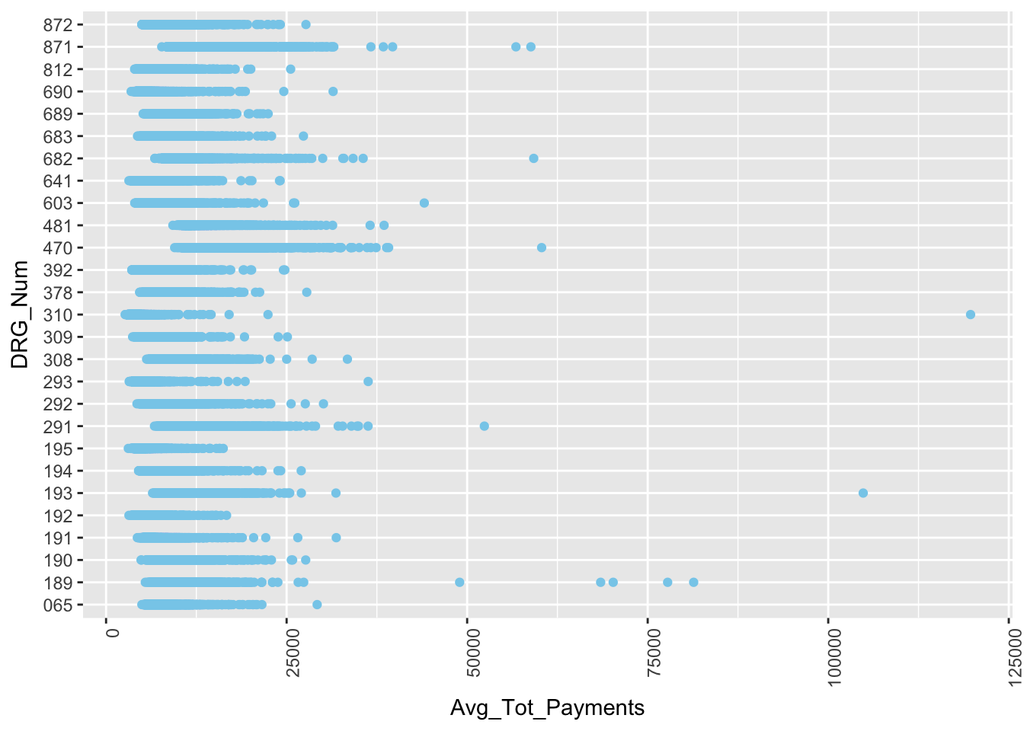

```r
# The graph of the third group, which has relatively many providers in each drug group
payment1 %>%
  filter(group_class=="1890_to_2837")%>%
  ggplot(aes(x=Avg_Tot_Payments, y=DRG_Num))+
  geom_point(colour="skyblue")+
  theme(axis.text.x = element_text(angle = 90, hjust = 1))+
  scale_y_discrete(label=abbreviate)
```

Here, as I mentioned, I divided the dataset into three groups: `1_to_945`, `946_to_1890`, and `1890_to_2837`:  
- `1_to_945`: The number of entities in a drug definition group (`DRG_Def`) is a range of 1 to 946  
- `946_to_1890`: The number of entities in a drug definition group (`DRG_Def`) is a range of 946 to 1890  
- `1890_to_2837`: The number of entities in a drug definition group (`DRG_Def`) is a range of 1890 to 2837

Then, I plotted `Avg_Tot_Payments` from only `1890_to_2837` group, to see the general trends.  
It looks like we see some outliers, though, we should not be so sure, since the price can also vary from states.

```r
# Making Three Columns after grouping by DRG_Num and Pro_State
payment1<-payment1 %>%
  group_by(DRG_Num, Pro_State) %>%
  mutate(Mu_DRG_State_Total_Payment=mean(Avg_Tot_Payments),
         Sd_DRG_State_Total_Payment=sd(Avg_Tot_Payments),
         Std_DRG_State_Total_Payment=(Avg_Tot_Payments-Mu_DRG_State_Total_Payment)/Sd_DRG_State_Total_Payment) %>%
  ungroup()

# Viewing some examples
payment1 %>%
  select(DRG_Num,Pro_State,Mu_DRG_State_Total_Payment,Sd_DRG_State_Total_Payment,Std_DRG_State_Total_Payment) %>%
  filter(DRG_Num=="310")%>%
  head()
```

```
## # A tibble: 6 x 5
##   DRG_Num Pro_State Mu_DRG_State_Tota~ Sd_DRG_State_Tot~ Std_DRG_State_To~
##   <chr>   <chr>                  <dbl>             <dbl>             <dbl>
## 1 310     AL                      3564               484            -0.182
## 2 310     AL                      3564               484            -0.209
## 3 310     AL                      3564               484            -0.770
## 4 310     AL                      3564               484            -0.550
## 5 310     AL                      3564               484             0.489
## 6 310     AL                      3564               484            -0.900
```

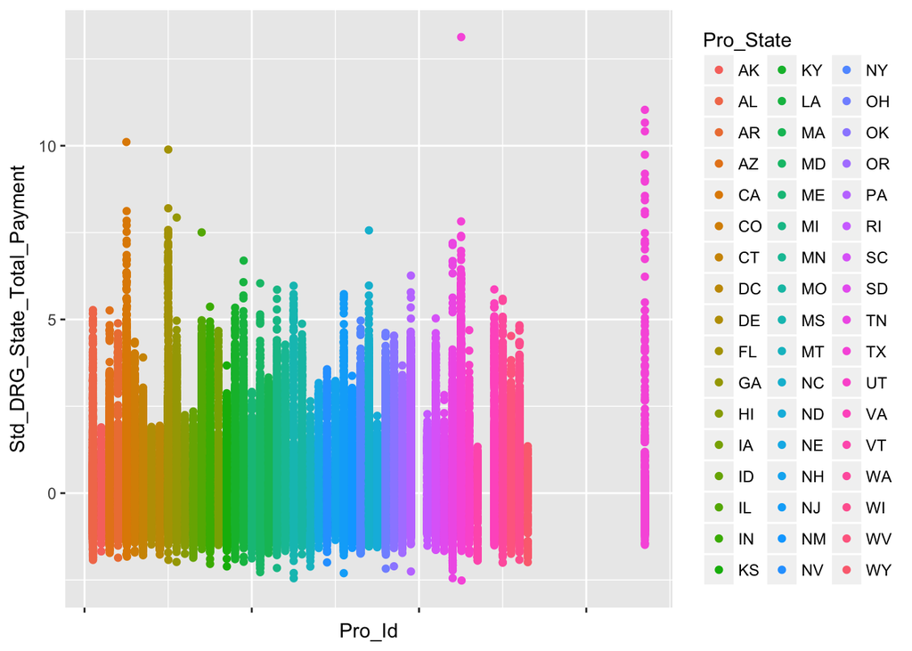

```r
# Plotting standardized total_payment
payment1 %>%
  filter(group_class=="1890_to_2837"|group_class=="946_to_1890" ) %>%
  ggplot(aes(x=Pro_Id, y=Std_DRG_State_Total_Payment))+
  geom_point(aes(color=Pro_State))+
  theme(axis.text.x = element_blank())
```

After dividing into three group depending on the number of providers in drug_definition,  
I filtered only the second and third group, which basically have more than 946 providers in each drug definition group.

I generated three columns as follows:  
- `Mu_DRG_State_Total_Payment`: Mean of `Avg_Tot_Payments` grouped by drug group (`Drug_Num`) and state (`Prov_State`).  
- `Sd_DRG_State_Total_Payment`: Standard deviation of `Avg_Tot_Payments` grouped by drug group (`Drug_Num`) and state (`Prov_State`).  
- `Std_DRG_State_Total_Payment`: Standardized `Avg_Tot_Payments` using Z-score with `Mu_DRG_State_Total_Payment` and `Sd_DRG_State_Total_Payment`

$$Z=\frac{X-\mu }{\sigma }=\frac{AvgTotalPayments-Mu(AvgTotalPayments)}{Sd(AvgTotalPayments)}$$

## 1.3 Conclusion

As we can see from the above colorful graph, we can notice a few distinctively high standardized values, comparing to the other providers. We might want to further exam those values.  
Since they were outliers even after they were standardized by the mean grouped by state and drug as well, I believe that it has room to be a fraud case.

# 2 Standardized Difference Between Medical Coverage and Medical Payment

## 2.1 Lead

According to [Data.CMS](https://data.cms.gov/Medicare-Inpatient/National-Summary-of-Inpatient-Charge-Data-by-Medic/efwk-h4x3), `Average Covered Charges` means the average charge of all provider’s services covered by Medicare for discharges in the DRG.  
Since this would vary from hospital to hospital, we should not simply assume a fraud, just because a provider overly charged Medicare to pay than they were supposed to cover.  
However, we can calculate the mean difference of `Average Covered Charges` and `Average Medicare Payments` per each Drug group, and see whether an entity has significant difference than the other in the same group.

## 2.2 EDA

```r
# Making Four New Columns
payment2<-payment1 %>%
  mutate(Diff_MedCov_MedPay=Avg_Cov_Charges-Avg_Med_Payments) %>%
  group_by(DRG_Num) %>%
  mutate(Mu_Diff=mean(Diff_MedCov_MedPay), Sd_Diff=sd(Diff_MedCov_MedPay)) %>%
  mutate(Standard_Diff=(Diff_MedCov_MedPay-Mu_Diff)/Sd_Diff)%>%
  ungroup()

payment2 %>%
  select(DRG_Num, Diff_MedCov_MedPay, Mu_Diff, Sd_Diff, Standard_Diff ) %>%
  head()
```

```
## # A tibble: 6 x 5
##   DRG_Num Diff_MedCov_MedPay Mu_Diff Sd_Diff Standard_Diff
##   <chr>                <dbl>   <dbl>   <dbl>         <dbl>
## 1 001                 873590  741485  441045         0.300
## 2 001                 214539  741485  441045        -1.19
## 3 001                 677462  741485  441045        -0.145
## 4 001                1284325  741485  441045         1.23
## 5 001                1131869  741485  441045         0.885
## 6 001                1046182  741485  441045         0.691
```

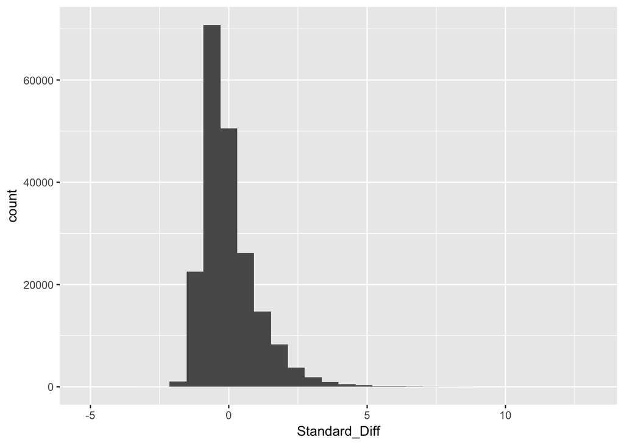

```r
# Plotting a histogram
payment2 %>%
  ggplot(aes(x=Standard_Diff))+
  geom_histogram()
```

```r
# Filtering intresting data
payment2 %>% filter(Standard_Diff < -2)
```

```
## # A tibble: 17 x 22
##    DRG_Def     Pro_Id Pro_Name   Pro_Add  Pro_City Pro_State Pro_Zip HRR
##    <chr>        <int> <chr>      <chr>    <chr>    <chr>       <int> <chr>
##  1 060 - MULT~ 190098 UNIVERSIT~ 1541 KI~ SHREVEP~ LA          71103 LA -~
##  2 191 - CHRO~  50373 LAC+USC M~ 1200 N ~ LOS ANG~ CA          90033 CA -~
##  3 227 - CARD~ 330204 BELLEVUE ~ 462 FIR~ NEW YORK NY          10016 NY -~
##  4 228 - OTHE~ 240010 MAYO CLIN~ 1216 SE~ ROCHEST~ MN          55902 MN -~
##  5 247 - PERC~ 330128 ELMHURST ~ 79-01 B~ ELMHURST NY          11373 NY -~
##  6 247 - PERC~ 330204 BELLEVUE ~ 462 FIR~ NEW YORK NY          10016 NY -~
##  7 652 - KIDN~ 210002 UNIVERSIT~ 22 SOUT~ BALTIMO~ MD          21201 MD -~
##  8 652 - KIDN~ 210009 JOHNS HOP~ 600 NOR~ BALTIMO~ MD          21287 MD -~
##  9 743 - UTER~ 190128 WOMAN'S H~ 100 WOM~ BATON R~ LA          70817 LA -~
## 10 743 - UTER~ 450674 WOMANS HO~ 7600 FA~ HOUSTON  TX          77054 TX -~
## 11 775 - VAGI~ 190128 WOMAN'S H~ 100 WOM~ BATON R~ LA          70817 LA -~
## 12 781 - OTHE~ 450674 WOMANS HO~ 7600 FA~ HOUSTON  TX          77054 TX -~
## 13 894 - ALCO~  50543 COLLEGE H~ 301 VIC~ COSTA M~ CA          92627 CA -~
## 14 894 - ALCO~ 230275 HEALTHSOU~ 3340 HO~ SAGINAW  MI          48603 MI -~
## 15 897 - ALCO~  50543 COLLEGE H~ 301 VIC~ COSTA M~ CA          92627 CA -~
## 16 897 - ALCO~ 230275 HEALTHSOU~ 3340 HO~ SAGINAW  MI          48603 MI -~
## 17 897 - ALCO~ 390025 KENSINGTO~ 136 W D~ PHILADE~ PA          19122 PA -~
## # ... with 14 more variables: Tot_Discharges <int>, Avg_Cov_Charges <dbl>,
## #   Avg_Tot_Payments <dbl>, Avg_Med_Payments <dbl>, DRG_Num <chr>,
## #   n_row_group <int>, group_class <fct>,
## #   Mu_DRG_State_Total_Payment <dbl>, Sd_DRG_State_Total_Payment <dbl>,
## #   Std_DRG_State_Total_Payment <dbl>, Diff_MedCov_MedPay <dbl>,
## #   Mu_Diff <dbl>, Sd_Diff <dbl>, Standard_Diff <dbl>
```

$$Z=\frac{X-\mu }{\sigma }=\frac{DiffMedCovMedPay-MuDiff}{Sd_Diff}$$

## 2.3 Conclusion

As we can see from the above graph, most of the providers were centered around zero. However, there were several providers with the standardized difference even less than -2.  
As such, I looked at the providers with the standardized difference even less than -2.  
As we can see from the above chart, there were $17$ providers who have a standardized difference of less than -2.  
This means the amount of money that Medicare paid to the providers was significantly higher than the amount to the other providers in the same drug definition.  
We may assume that those cases have a possibility to be a fraud, and examine them.